# Caregivers and PTSD Project Notebook

2026-03-06

## Configuration

### Load Packages

```r
library(brms)      # Bayesian modeling
library(tidybayes) # For post-processing
library(cmdstanr)  # MCMC sampling
```

```r
library(lavaan)    # Internal consistency
library(dagitty)   # Specifying & Analyzing DAGs
library(ggdag)     # Drawing DAGs
library(ggtext)    # Fonts for graphs
library(showtext)  # To display fonts
library(posterior) # Extract posterior draws
library(here)      # For relative paths
library(MASS)      # mvrnorm
library(tidyverse, quietly = TRUE) # Data wrangling
library(conflicted) # to resolve conflicted functions


conflicts_prefer(
  dplyr::select,
  dplyr::filter,
  dplyr::lag,
  posterior::match,
  posterior::mad,
  posterior::sd,
  posterior::var,
  brms::ar,
  brms::rstudent_t,
  brms::dstudent_t,
  brms::pstudent_t,
  brms::qstudent_t)
```

### Import Data

Read the data using a script stored in `R/`.

```r
source(here::here("R/import.R"))
```

### MCMC Sampling Options

```r
options(mc.cores = parallel::detectCores())
options(brms.backend = "cmdstanr")
```

### Theme Settings

```r
font_add_google("Karla", family = "karla")
font_add_google("Cardo", family = "cardo")
showtext_auto()
colors_johnson <- MetBrewer::MetPalettes$Johnson[[1]]
c("#a00e00", "#d04e00", "#f6c200", "#0086a8", "#132b69")
```

```
## [1] "#a00e00" "#d04e00" "#f6c200" "#0086a8" "#132b69"
```

```r
theme_density <-
  theme(
    # Remove the legend
    legend.position = 'none',

    # Panel customization
    panel.background = element_rect(fill = "white", color = "white"),
    panel.grid.major.x = element_line(color = "#e9e9e9", linewidth = .3),
    panel.grid.minor.x = element_line(color = "#e9e9e9", linewidth = .1),
    panel.grid.major.y = element_blank(),

    # Axis customization
    #axis.line = element_line(color = "#3e3e3e"),
    axis.line.y.left = element_blank(),
    axis.title = element_markdown(size = 10, face = "bold"),
    axis.title.y = element_markdown(margin = margin(r = 20)),
    axis.text.y = element_blank(),
    axis.ticks = element_blank(),

    # Title customization
    plot.title = element_markdown(size = 14, face = "bold"),
    plot.subtitle = element_markdown(size = 12, color = "#3e3e3e"),
    plot.caption = element_markdown(hjust = 0, color = "#7e7e7e"),

    # Strip customization
    strip.background = element_rect(fill = "white"),
    strip.text = element_text(face = "bold")
  )
```

## Scientific Model

We are researching the mental health of veterans who are caregivers and care recipients. We suspect veteran caregivers will be more likely to experience PTSD and stress, anxiety, and depression, all of which may affect the quality of care they provide to their care recipients. Apart from their own military background that can affect their health, veterans may be more likely to care for other veterans, which in turn may affect the caregiver’s mental health.

We have five hypotheses.

- H1: Depression, Anxiety, and Stress will be worse for caregivers who are veterans.
- H2: Depression, Anxiety, and Stress will be worse for caregivers to veterans than caregivers to non-veterans.
- H3: Depression, Anxiety, and Stress will be worse for caregivers with probable PTSD.
- H4: Probable PTSD will be more prevalent in veteran caregivers.
- H5: Probable PTSD will be more prevalent in caregivers to veterans than caregivers to non-veterans.

These hypotheses are captured by the following directed acyclic graph (DAG):

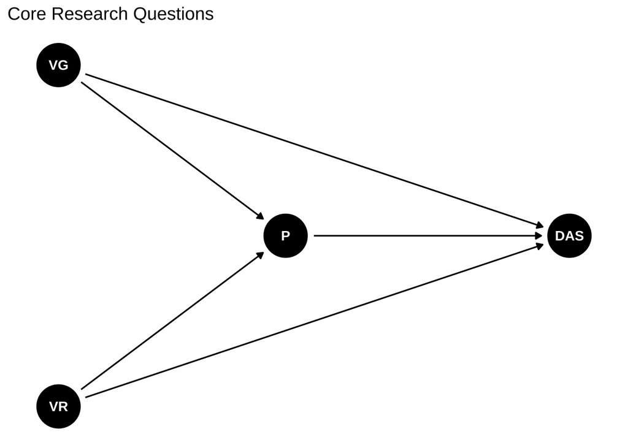

```r
# specify the DAG
dag_core <-
  dagify(
    DAS ~ P + VG + VR,
    P ~ VR + VG,
    exposure = 'P',
    coords = list(
       x = c(VR = -.15, VG = -.15, P = .05, DAS = .3),
       y = c(VR = -.07,VG = .07, P = 0, DAS = 0))
      )

# Add descriptive labels
dag_core_tidy <-
  dag_core %>%
  tidy_dagitty() %>%
  mutate(
    label = case_when(
      name == "VG" ~ "Vet Giver",
      name == "VR" ~ "Vet Recipient",
      name == "P" ~ "PTSD",
      name == "DAS" ~ "DAS",
      .default = name))

# Create a stylized graph
plot_dag_core <-
  dag_core_tidy %>%
  ggplot(aes(x = .data$x, y = .data$y, xend = .data$xend, yend = .data$yend)) +
  geom_dag_text(color = 'black', size = 34, family = "karla", fontface = "plain") +
  geom_dag_text(aes(label = label), size = 12, color = colors_johnson[4], nudge_y = -.0185, nudge_x = -.000005, fontface = "italic", family = "cardo") +
  geom_dag_edges(
    curvature = .5,
    start_cap = ggraph::circle(15, 'mm'),
    end_cap = ggraph::circle(12, 'mm'),
    edge_color = "grey10",
    edge_width = .45
    ) +
  theme_dag_blank() +
  lims(x = c(-.45,.40))

# Save stylized graph to file
ggsave(plot = plot_dag_core, here::here('output/dag-core.jpg'), height = 4, width = 6)

# Print simple graph to console/markdown
dag_core %>% ggdag() + ggdag::theme_dag() + labs(title = "Core Research Questions")
```

### Estimands

Counting depression, anxiety, and stress separately, that implies 11 estimands.

## Sample Size

```r
data %>% nrow()
```

```
## [1] 270
```

## Examine Measures

Let’s make sure the scales we used have the expected internal consistency. We will calculate $\omega$ for each DASS-21 subscale.

### Depression DASS-21

```r
fit_depression <-
  lavaan::cfa(model = "depression =~ dass_3 + dass_5 + dass_10 + dass_13 + dass_16 + dass_17 + dass_21",
              data,
              std.lv = TRUE,
              ordered = c('dass_3','dass_5','dass_10',
                          'dass_13','dass_16','dass_17',
                          'dass_21'),
              estimator = "WLSMV")
reliability_depression <-
  semTools::compRelSEM(fit_depression,
                       obs.var = TRUE,
                       tau.eq = FALSE,
                       ord.scale = TRUE,
                       return.df = TRUE)
reliability_depression
```

```
## depression
##       0.93
```

### Anxiety DASS-21

```r
str_items <- paste0("DASS", c(1,6,8,11,12,14,18))

fit_anxiety <-
  lavaan::cfa(model = "anxiety =~ dass_2 + dass_4 + dass_7 + dass_9 + dass_15 + dass_19 + dass_20",
              data,
              std.lv = TRUE,
              ordered = c('dass_2','dass_4','dass_7',
                          'dass_9','dass_15','dass_19',
                          'dass_20'),
              estimator = "WLSMV")
reliability_anxiety <-
  semTools::compRelSEM(fit_anxiety,
                       obs.var = TRUE,
                       tau.eq = FALSE,
                       ord.scale = TRUE,
                       return.df = TRUE)
reliability_anxiety
```

```
## anxiety
##   0.926
```

### Stress DASS-21

```r
fit_stress <-
  lavaan::cfa(model = "stress =~ dass_1 + dass_6 + dass_8 + dass_11 + dass_12 + dass_14 + dass_18",
              data,
              std.lv = TRUE,
              ordered = c('dass_1','dass_6','dass_8',
                          'dass_11','dass_12','dass_14',
                          'dass_18'),
              estimator = "WLSMV")
reliability_stress <-
  semTools::compRelSEM(fit_stress,
                       obs.var = TRUE,
                       tau.eq = FALSE,
                       ord.scale = TRUE,
                       return.df = TRUE)
reliability_stress
```

```
## stress
##  0.913
```

## Examine Variables

### PTSD

```r
data %>% count(recipient_veteran, pc_ptsd_positive_screen)
```

```
## # A tibble: 4 × 3
##   recipient_veteran pc_ptsd_positive_screen     n
##               <dbl>                   <dbl> <int>
## 1                 0                       0   155
## 2                 0                       1    53
## 3                 1                       0    34
## 4                 1                       1    28
```

## Generative Model

We have a triple-headed outcome: depression, anxiety, and stress. This is a classic multivariate setup (e.g., MANOVA) that models multiple outcomes. Let’s fit a multivariate Bayesian regression with correlated residuals across stress, anxiety, and depression. This will account for shared variance among the outcomes, modelling each outcome with a consistent set of explanatory variables. To determine which covariates to use, we will add additional variables to the DAG.

### DAG

What additional variables might affect the simple four-variable system we laid out above?: **1. Demographics:** A caregiver’s Gender Identity (G), Age (A), Racial Identity (R), Income (I), and Education (E) might all plausibly affect their level of Depression, Anxiety, and Stress (DAS) as well as PTSD (P). **2. Characteristics of Care:** The characteristics of the caregiving situation may affect a caregiver’s mental health, including the care recipient’s condition, relation to the caregiver, and intensity of caregiver duties. These characteristic may be affected by the veteran status of the recipient (VR). Indeed, PTSD is one specific type of condition, one that we care about for the purposes of the current study. Thus, we consider several of these characteristics to be mediators between VR and DAS: Hours per week providing care (H), knowledge of veteran caregiving benefits (K), and recipient condition (C). There are likely others, but given these are “post-treatment” (i.e., consequences of veterans status), we do not need to model all of them in the DAG, as they will not be adjusted for anyways. But there may be other factors that should be added, so instead of a generic mediator variable, we will leave these specific ones for now. (Note, after looking at the data, only people caring for veterans were asked their knowledge of veteran benefits…also leaving it in is simply inconvenient: it adds an additional model. I’m inclined to remove it due to missingness and for more simplicity in the modelling)

What relates veteran status of the caregiver to veteran status of the care recipient?: **1. Marriage:** Service members (turned veterans) may be more likely to marry (M) other service members (turned veterans). Spouses are a potential relative people care for. **2. Family:** People from a military family (F) may all be more likely to join the military, for instance, if your grandparent or parent served in the military. Family members are other relatives that people in general may care for.

What relates these additional variables to each other? **1. Pre-Military Background:** A person’s pre-military background, specifically their socioeconomic status (S), might affect a host of variables, including their observed income, education, and veteran status. Their pre-military socioeconomic status might also be affected by their racial identity or if they came from a military family.

Let’s specify these assumptions in a DAG:

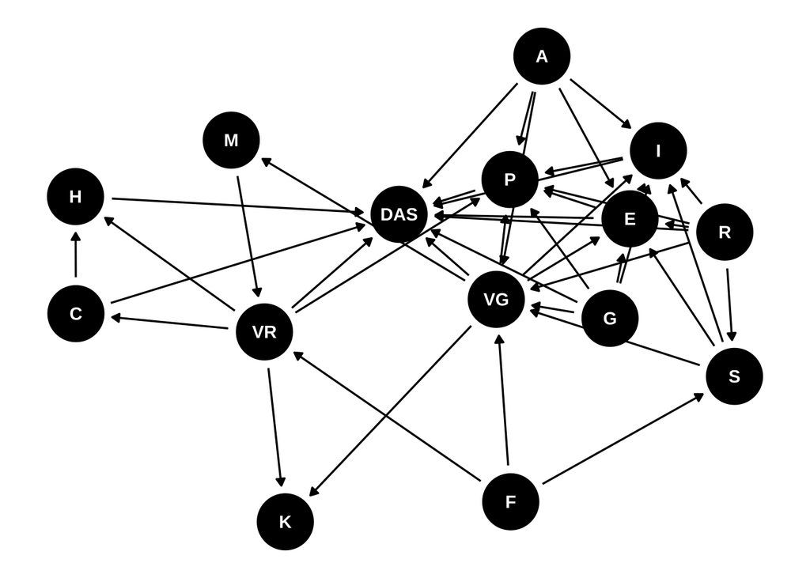

```r
dag_full <-
  dagify(
    DAS ~ VG + VR + P + H + C + I + E + G + A + R,
    VR ~ `F` + M,
    VG ~ `F` + S + G + A + R,
    P ~ VR + VG + G + A + R + I + E,
    H ~ VR + C,
    C ~ VR,
    K ~ VR + VG,
    M ~ VG,
    S ~ `F` + R,
    E ~ VG + S + G + A + R,
    I ~ VG + S + E + G + A + R)
dag_full %>%  ggdag() + ggdag::theme_dag()
```

```r
# Tell the DAG what is not measured
dag_full <- setVariableStatus(dag_full, "latent", c("S", "M", "F"))
```

**Consider Hypothesis 1 (H1): DAS ~ Veteran Caregiver (VG).**

Without a measure of Military Family (F), there is no way to identify the total effect. The main hindrance is how we specify the relationship between being a veteran and also having to care for a veteran (or not). As is, we assume that veterans have an increased chance of caring for other veterans. This could be through marriage, in which case a person becoming a service member made them more likely to get married to another service member; and if caring for a spouse, then the care recipient would be a veteran. But there is also another way that the veteran status of both caregiver and recipient are the same: they share a common non-marital family. In the US, military service runs in families, so veterans who are caring for parents or older relatives are more likely to be caring for veterans.

Thus, the Veteran Recipient (VR) variable is both a mediator of veteran caregiver status on mental health, but also it shares a common, unmeasured cause of Military Family. If you include VR in the model, you block the confounding path from Military Family but you also block the mediating path, conditioning on a post-treatment variable.

```r
adjustmentSets(dag_full, exposure = "VG", outcome = "DAS", effect = "total")
```

However, the direct effect can be identified.:

```r
adjustmentSets(dag_full, exposure = "VG", outcome = "DAS", effect = "direct")
```

```
## { A, E, G, I, P, R, VR }
```

It is a long list of variables. Why is that? Some of these are common causes are therefore need to be adjusted (i.e., A, G, R). Others are indirect effects and need to be adjusted (i.e., I, E, P).

VR serves as a mediator via the unmeasured M, so it’s an indirect effect.

**H2: DAS ~ Veteran Recipient (VR)**

The total effect is identifiable. This adjustment set is almost identical to the direct effect set above, but it excludes the mediator P.

```r
adjustmentSets(dag_full, exposure = "VR", outcome = "DAS", effect = "total")
```

```
## { A, E, G, I, R, VG }
```

**H3: DAS ~ PTSD (P)**

The total effect is identifiable. This looks like the one above, but PTSD is the exposure and thus veteran status of caregiver and recipient are adjusted for.

```r
adjustmentSets(dag_full, exposure = "P", outcome = "DAS", effect = "total")
```

```
## { A, E, G, I, R, VG, VR }
```

**H4: P ~ VG**

Like with DAS, the total effect of caregiver veteran status is not identifiable for PTSD as an outcome:

```r
adjustmentSets(dag_full, exposure = "VG", outcome = "P", effect = "total")
```

But the direct effect is:

```r
adjustmentSets(dag_full, exposure = "VG", outcome = "P", effect = "direct")
```

```
## { A, E, G, I, R, VR }
```

**H5: P ~ VR**

And the total effect on PTSD is identifiable for the recipient’s veteran status:

```r
adjustmentSets(dag_full, exposure = "VR", outcome = "P", effect = "total")
```

```
## { A, E, G, I, R, VG }
```

H1 (direct effect), H2 (total effect), and H3 (total effect) can be estimated with the same model, only for H2 I need to marginalize over the values of P if P is included in the model. H4 (direct effect) and H5 (total effect) entail the same outcome and explanatory variables, so they can be assessed with the same statistical model. The models are:

H1. DAS ~ P + VG + VR + A + E + G + I + R H2. DAS ~ VG + VR + A + E + G + I + R H3. DAS ~ P + VG + VR + A + E + G + I + R H4. P ~ VG + VR + A + E + G + I + R H5. P ~ VG + VR + A + E + G + I + R

Which becomes: 1. DAS ~ P + VG + VR + A + E + G + I + R 2. P ~ VG + VR + A + E + G + I + R

## Statistical Model

We will use multivariate multiple regression, modelling the three outcomes (DAS) as a function of the explanatory variables and covariates identified by the DAGs.

Stress, depression, and anxiety are correlated mental health issues; they tend to hang together. Moreover, people differ in personal traits that can affect these different issues simultaneously.

Given these individual traits, a person might tend to score high on stress, anxiety, and depression relative to what the explanatory variable and covariates would predict. So we need to model these 3 outcomes together, all predicted by the same variables, but also allowed for the part that isn’t predicted by these variable (i.e., “error”) to co-vary apart from the explanatory variables.

### Likelihood

This means the likelihood of the joint outcome $y_i$ is modeled as a multivariate normal distribution with parameters $\mu$ and $\Sigma$.

$$\begin{align}
& y_i \sim MVNormal(\mu_i, \Sigma) \\
\end{align}$$

$$\mu_i =
\begin{pmatrix}
x_i^{\top} \beta_d \\
x_i^{\top} \beta_a \\
x_i^{\top} \beta_s
\end{pmatrix}$$

$\Sigma$ is a residual covariance matrix between the three outcomes.

$$\Sigma =
\begin{pmatrix}
\sigma_d^2 & \rho_{da}\sigma_d\sigma_a &
\rho_{ds}\sigma_d\sigma_s \\
\rho_{da}\sigma_d\sigma_a & \sigma_a^2 &
\rho_{as}\sigma_a\sigma_s \\
\rho_{ds}\sigma_d\sigma_s & \rho_{as}\sigma_a\sigma_s &
\sigma_s^2
\end{pmatrix}$$

Where $\rho_{da}, \rho_{as}, \rho_{ds}$ are the correlated residuals between outcomes – the extent to which the variation in the outcomes not explained by the IVs is shared among the DVs – and $\sigma_d, \sigma_a, \sigma_s$ the standard deviations of the residuals which are the unique, un-shared error of each outcome.

### Priors

When determining priors, always consider the scale of the variables.

The predictor variables of interest (VG, VR, and PTSD) are binary 0-1: Non-Veteran/Veteran of both recipient and caregiver or probable PTSD detected/not detected. The 0 represents the absence of Veteran status or PTSD. Most of the covariates are categorical, and thus they will also be 0/1 dummy-coded. Age is the exception.

We will standardize the outcomes to make selecting priors easier. This also makes the coefficient standardized rather than unstandardized (e.g., $b$ to $beta$).

The intercept represents the mean for the reference group (0s). The beta represents the difference between groups (0-1). $\text{Normal}(0, 1)$ is reasonable for both. That means I think the predicted outcome of the reference group will be +-2SD of the mean in 95% of cases, and more likely within -+1 SD.

#### Standardize the variables

```r
data <-
  data %>%
  mutate(dass_depression_z = as.numeric(scale(dass_depression)),
         dass_anxiety_z = as.numeric(scale(dass_anxiety)),
         dass_stress_z = as.numeric(scale(dass_stress))
         )
```

For the prior on the standard error $\sigma$, we need a positive real number, because standard errors are always positive. By standardizing the outcome variables, the variables have been scaled to have a SD = 1. So the prior should be something make make 1 and the values near it highly plausible. Say a half-student-t(3, 0, 1) or a half-Cauchy(0,1)

For the prior on the residual covariance, I’ll use the $\text{LJKcorr}(2)$ which is a standard choice for covariance matrices (McElreath, 2015) and is more skeptical of extreme correlations near 1 or -1 than it is correlations closer to 0.

$$\begin{align}
& \beta \sim \text{Normal}(0, 1) \\
& \alpha \sim \text{Normal}(0, 1) \\
& \sigma \sim \text{half-Student-t}(3, 0, 1) \\
& \Sigma \sim \text{LJKcorr}(2)
\end{align}$$

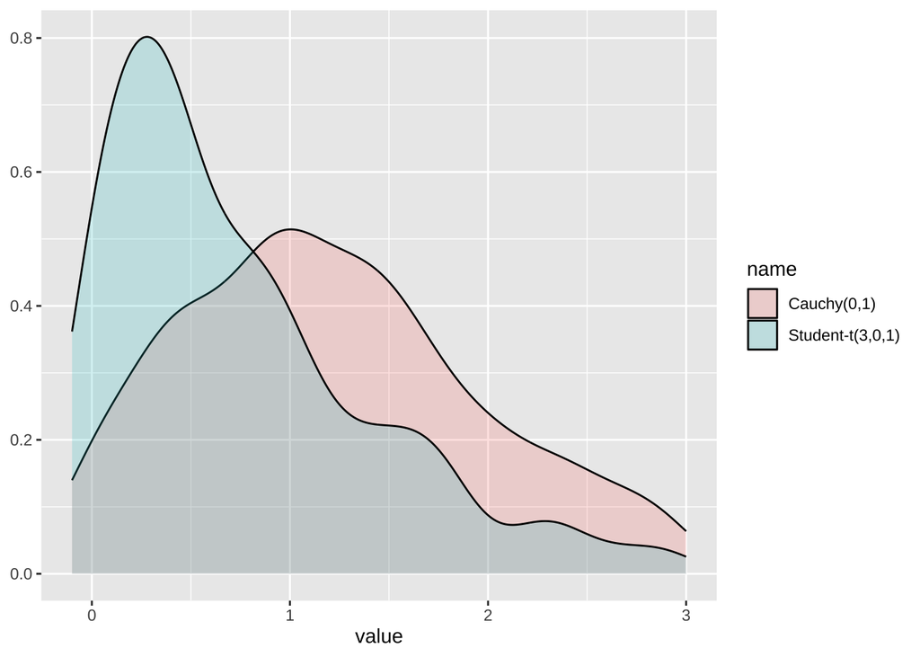

```r
tibble(`Cauchy(0,1)` = rcauchy(1000, 1, 1),
       `Student-t(3,0,1)` = rstudent_t(n = 1000, 3, 0, 1)) %>% pivot_longer(everything()) %>%  ggplot(aes(value, fill = name)) + geom_density(alpha = .2) + lims(x = c(-.1, 3)) + labs(y = NULL)
```

#### Prior Predictive Check

… need to specify the model in brms/stan first to be able to sample from it.

## Simulation Model

### Simulate some data

```r
set.seed(30144)
n <- 300

# regression coefficients (one per outcome)
beta_VG <- c(d = 0.5, s = 0.3, a = 0.2)
beta_VR <- c(d = 0.5, s = 0.3, a = 0.2)
beta_PTSD <- c(d = 0.7, s = 0.7, a = 0.7)

# residual covariance
Sigma <- matrix(
  c(1.0, 0.6, 0.5,
    0.6, 1.0, 0.4,
    0.5, 0.4, 1.0),
  nrow = 3
)

# correlated errors
E <- MASS::mvrnorm(n, mu = c(0, 0, 0), Sigma = Sigma)

## Data
data_sim <-
  tibble(
    mil_family = rbinom(n, size = 1, prob = .4),
    VG = ifelse(mil_family == 1,
                rbinom(n, size = 1, prob = .5),
                rbinom(n, size = 1, prob = .2)),
    VR = ifelse(mil_family == 1,
                rbinom(n, size = 1, prob = .5),
                rbinom(n, size = 1, prob = .25))
) %>%
  rowwise() %>%
  mutate(pc_ptsd_positive_screen =
          rbinom(n = 1, size = 1,
                 prob = plogis(VR * .2 + VG * .2 + rnorm(1, 0, .2)))) %>%
  ungroup() %>%
  mutate(
    dass_depression_z =
      beta_VR["d"] * VR +
      beta_VG["d"] * VG +
      beta_PTSD["d"] * pc_ptsd_positive_screen +
      E[,1],
    dass_stress_z =
      beta_VR["s"] *
      VR + beta_VG["s"] *
      beta_PTSD["s"] * pc_ptsd_positive_screen +
      VG + E[,2],
    dass_anxiety_z =
      beta_VR["a"] * VR +
      beta_VG["a"] * VG +
      beta_PTSD["a"] * pc_ptsd_positive_screen +
      E[,3]) %>%
  rename(caregiver_veteran = VG,
         recipient_veteran = VR) %>%
  # Add demographic covariates...without coefficients, just to see the models run
  rowwise() %>%
  mutate(race = sample(c('white', 'Black', 'other'), size = 1),
         gender_female = rbinom(1, 1, prob = .5),
         education = sample(c("lower", "average", "higher"), size = 1),
         income = sample(c("lower", "average", "higher"), size = 1),
         age = rnorm(n = 1, mean = 0, sd = 1)
         ) %>%
  ungroup() %>%
  mutate(race_black = ifelse(race == 'Black', 1, 0),
         race_white = ifelse(race == 'white', 1, 0),
         education_higher = ifelse(education == "higher", 1, 0),
         education_lower = ifelse(education == "lower", 1, 0),
         income_higher = ifelse(income == "higher", 1, 0),
         income_lower = ifelse(income == "lower", 1, 0)
         )

head(data_sim)
```

```
## # A tibble: 6 × 18
##   mil_family caregiver_veteran recipient_veteran pc_ptsd_positive_screen
##        <int>             <int>             <int>                   <int>
## 1          1                 1                 1                       0
## 2          1                 1                 0                       0
## 3          1                 1                 0                       1
## 4          1                 0                 0                       0
## 5          1                 0                 1                       0
## 6          1                 0                 1                       0
## # ℹ 14 more variables: dass_depression_z <dbl>, dass_stress_z <dbl>,
## #   dass_anxiety_z <dbl>, race <chr>, gender_female <int>, education <chr>,
## #   income <chr>, age <dbl>, race_black <dbl>, race_white <dbl>,
## #   education_higher <dbl>, education_lower <dbl>, income_higher <dbl>,
## #   income_lower <dbl>
```

### Set Priors

```r
priors <- c(
  # Residual correlation shrinkage
  prior(lkj(2), class = "rescor"),

  # Stress
  prior(normal(0, 0.5), class = "Intercept", resp = "dassstressz"),
  prior(normal(0, 0.5), class = "b", resp = "dassstressz"),
  prior(normal(0, 0.7), class = "sigma", resp = "dassstressz"),

  # Anxiety
  prior(normal(0, 0.5), class = "Intercept", resp = "dassanxietyz"),
  prior(normal(0, 0.5), class = "b", resp = "dassanxietyz"),
  prior(normal(0, 0.7), class = "sigma", resp = "dassanxietyz"),

  # Depression
  prior(normal(0, 0.5), class = "Intercept", resp = "dassdepressionz"),
  prior(normal(0, 0.5), class = "b", resp = "dassdepressionz"),
  prior(normal(0, 0.7), class = "sigma", resp = "dassdepressionz")
)
```

### Fit with brms

Fit the simulation data to the model using brms

Recall, the models are: H1/H3. DAS ~ P + VG + VR + A + E + G + I + R H2. DAS ~ VG + VR + A + E + G + I + R H4/H5. P ~ VG + VR + A + E + G + I + R

```r
fit_h1_h3 <-
  brm(
    bf(dass_stress_z ~ 1 + pc_ptsd_positive_screen + recipient_veteran + caregiver_veteran + age + education_higher + education_lower + gender_female + income_higher + income_lower + race_black + race_white) +
    bf(dass_anxiety_z ~ 1 + pc_ptsd_positive_screen + recipient_veteran + caregiver_veteran + age + education_higher + education_lower + gender_female + income_higher + income_lower + race_black + race_white) +
    bf(dass_depression_z ~ 1 + pc_ptsd_positive_screen + recipient_veteran + caregiver_veteran + age + education_higher + education_lower + gender_female + income_higher + income_lower + race_black + race_white) +
    set_rescor(TRUE),
  prior = priors,
  data = data_sim,
  family = gaussian(),
  chains = 4, cores = 4, warmup = 2000, iter = 6000,
  silent = 0
)

fit_h2 <-
  brm(
    bf(dass_stress_z ~ 1 + recipient_veteran + caregiver_veteran + age + education_higher + education_lower + gender_female + income_higher + income_lower + race_black + race_white) +
    bf(dass_anxiety_z ~ 1 + recipient_veteran + caregiver_veteran + age + education_higher + education_lower + gender_female + income_higher + income_lower + race_black + race_white) +
    bf(dass_depression_z ~ 1 + recipient_veteran + caregiver_veteran + age + education_higher + education_lower + gender_female + income_higher + income_lower + race_black + race_white) +
    set_rescor(TRUE),
  prior = priors,
  data = data_sim,
  family = gaussian(),
  chains = 4, cores = 4, warmup = 2000, iter = 6000,
  silent = 0
)

fit_h4_h5 <-
  brm(
    bf(pc_ptsd_positive_screen ~ 1 + recipient_veteran + caregiver_veteran + age + education_higher + education_lower + gender_female + income_higher + income_lower + race_black + race_white, family = bernoulli(link = "logit")),
  prior = c(
    prior(normal(0, 1), class = "Intercept"),
    prior(normal(0, 1), class = "b")
  ),
  data = data_sim,
  family = bernoulli(link = "logit"),
  chains = 4, cores = 4, warmup = 2000, iter = 6000,
  silent = 0
)
```

```r
fit_h1_h3 %>% tidy_draws() %>% summarise_draws() %>% head()
```

```
## # A tibble: 6 × 10
##   variable       mean  median    sd   mad       q5   q95  rhat ess_bulk ess_tail
##   <chr>         <dbl>   <dbl> <dbl> <dbl>    <dbl> <dbl> <dbl>    <dbl>    <dbl>
## 1 b_dassstre… -0.0985 -0.0986 0.168 0.169 -0.373   0.176 1.00    18755.   12169.
## 2 b_dassanxi… -0.104  -0.103  0.170 0.171 -0.380   0.174 1.00    19492.   13407.
## 3 b_dassdepr… -0.0497 -0.0508 0.168 0.166 -0.325   0.226 1.00    16731.   12878.
## 4 b_dassstre…  0.277   0.277  0.112 0.110  0.0920  0.462 1.00    21369.   13455.
## 5 b_dassstre…  0.198   0.197  0.114 0.114  0.00999 0.386 1.00    21045.   12923.
## 6 b_dassstre…  0.992   0.993  0.122 0.122  0.791   1.19  1.000   20420.   13385.
```

```r
fit_h2  %>% tidy_draws() %>% summarise_draws() %>% head()
```

```
## # A tibble: 6 × 10
##   variable    mean  median     sd    mad      q5     q95  rhat ess_bulk ess_tail
##   <chr>      <dbl>   <dbl>  <dbl>  <dbl>   <dbl>   <dbl> <dbl>    <dbl>    <dbl>
## 1 b_dasss…  0.0204  0.0199 0.163  0.163  -0.249   0.288  1.000   17082.   12551.
## 2 b_dassa…  0.224   0.224  0.176  0.176  -0.0700  0.512  1.00    19135.   13333.
## 3 b_dassd…  0.215   0.216  0.169  0.171  -0.0629  0.488  1.00    16954.   12728.
## 4 b_dasss…  0.203   0.203  0.115  0.116   0.0137  0.391  1.000   19192.   14112.
## 5 b_dasss…  1.03    1.03   0.121  0.120   0.827   1.22   1.00    19932.   13719.
## 6 b_dasss… -0.147  -0.147  0.0540 0.0537 -0.236  -0.0577 1.00    18217.   12388.
```

```r
fit_h4_h5  %>% tidy_draws() %>% summarise_draws() %>% head()
```

```
## # A tibble: 6 × 10
##   variable        mean   median    sd   mad     q5   q95  rhat ess_bulk ess_tail
##   <chr>          <dbl>    <dbl> <dbl> <dbl>  <dbl> <dbl> <dbl>    <dbl>    <dbl>
## 1 b_Intercept -0.391   -0.392   0.348 0.347 -0.970 0.177 1.00    25946.   12050.
## 2 b_recipien…  0.0941   0.0940  0.246 0.245 -0.314 0.496 1.00    32209.   12032.
## 3 b_caregive…  0.644    0.642   0.266 0.266  0.212 1.08  1.00    29549.   12174.
## 4 b_age        0.00506  0.00502 0.112 0.109 -0.180 0.189 1.00    30534.   10768.
## 5 b_educatio…  0.0326   0.0328  0.276 0.273 -0.422 0.484 1.00    23140.   13522.
## 6 b_educatio…  0.185    0.185   0.290 0.286 -0.293 0.664 1.000   24310.   13254.
```

The model did a decent job recovering the parameters of the simulated data.

### Fit with Stan

One issue is that `brms` has problems fitting the models with DAS as an outcome and PTSD simultaneously. The issue is the inclusion of the residual covariance matrix. `brms` wants to estimate a covariance matrix for all four of these outcomes, which would be fine if we just ignore the covariance with PTSD. But `brms` will not run it beacuse it can only do the residual correlation on continuous variables not the binary outcome.

If we want to sample all of these models simultaneously, we need to implement this in Stan.:

```r
# Create a matrix of predictor variables
X <-
  data_sim %>%
  # center by subtracting 0.5
  transmute(
    VG = recipient_veteran - 0.5,
    VR = caregiver_veteran - 0.5,
    Rb = race_black - 0.5,
    Rw = race_white - 0.5,
    Gf = gender_female - 0.5,
    Eh = education_higher - 0.5,
    El = education_lower - 0.5,
    Ih = income_higher - 0.5,
    Il = income_lower - 0.5,
    A = age,
  ) %>% as.matrix()


# Gather the variables for the stan model
stan_data <-
  list(
    N = nrow(data_sim),
    X = X,
    K = ncol(X),
    P = data_sim$pc_ptsd_positive_screen,
    Y = as.matrix(
    data_sim[, c("dass_depression_z",
                 "dass_anxiety_z",
                 "dass_stress_z"
                 )]),
    prior_only = 0L
  )
# Create prior only data
stan_data_prior <- within(stan_data, prior_only <- 1L)

# Compile the stan code
model <- cmdstan_model("Stan/model.stan")
```

#### Prior predictive check

```r
# Fit the priors only
fit_prior <-
  model$sample(
    data = stan_data_prior,
    chains = 4,
    parallel_chains = 4,
    iter_warmup = 2000,
    iter_sampling = 6000,
    seed = 30144
)
```

Check Sampling Diagnoses on the prior pred check:

```r
fit_prior$cmdstan_diagnose()
```

```
## Checking sampler transitions treedepth.
## Treedepth satisfactory for all transitions.
##
## Checking sampler transitions for divergences.
## No divergent transitions found.
##
## Checking E-BFMI - sampler transitions HMC potential energy.
## E-BFMI satisfactory.
##
## Rank-normalized split effective sample size satisfactory for all parameters.
##
## Rank-normalized split R-hat values satisfactory for all parameters.
##
## Processing complete, no problems detected.
```

Plot the prior predictions

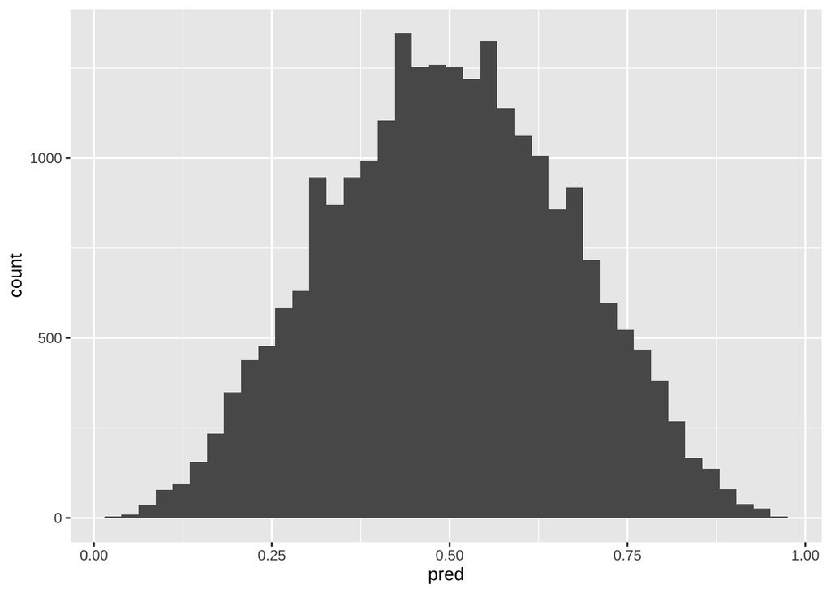

```r
draws_pred <- fit_prior$draws(c("P_rep", "Y_rep"))
draws_pred <- as_draws_df(draws_pred)

# Prior predictive prevalence of P
p_pred <-
  draws_pred %>%
  transmute(.draw, pred = rowMeans(across(starts_with("P_rep["))))
ggplot(p_pred, aes(x = pred)) + geom_histogram(bins = 40)
```

Priors on the logistic regression look fine, with the prior predictions centered normally around .5

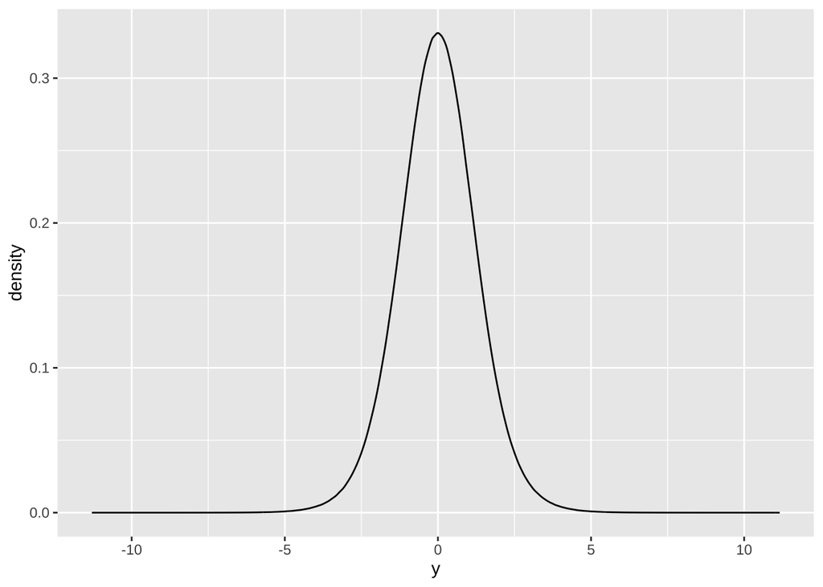

```r
# Prior predictive distribution of Y (pooled)
y_long <-
  draws_pred %>%
  dplyr::select(starts_with("Y_rep[")) |>
  pivot_longer(everything(), values_to = "y")
ggplot(y_long, aes(x = y)) + geom_density()
```

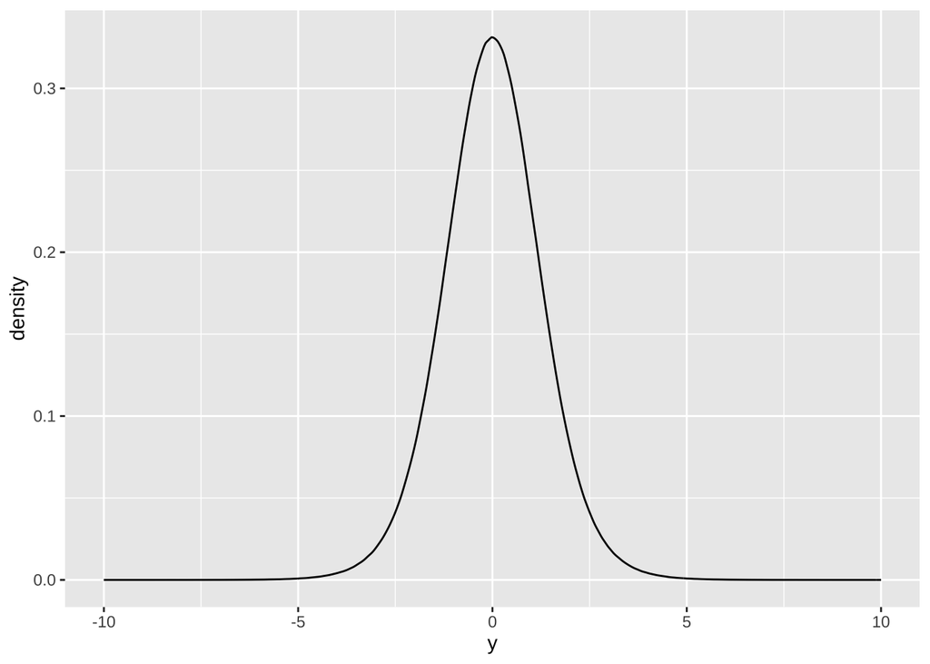

```r
ggplot(y_long, aes(x = y)) + geom_density() + lims(x = c(-10, 10))
```

But with the priors of beta = N(0,1), the range of possible values is too wide (-400, 200). I’ll restrict it to N(0, 0.5) and refit. That was even worse. That suggests the priors on the other parameters (e.g., sigma) are the issue. Let me reset the beta prior to N(0,1). I’ll adjust the prior on sigma from a half-student t to a half-normal N(0, 0.75). That looks much better (-20, 20). Now to tighten the coefficient and intercept priors slightly, from N(0,1) to N(0, 0.75). That did a little but not much. It isn’t terrible as is, with most the density between -5 and 5, which is a little wide. -3 and 3 would be better. I’l tigten to N(0, 0.5). That didn’t make a difference on the bulk of the probability mass, but did cut down a few extreme values. That means I might tigten sigma a little more, from N(0, .75) to N(0, 0.7). Ok, yes, that did it. All values are between -11 and 11, and the bulk are between -3 and 3.

As a final tweak, let me tigten the LKJ from 2 to 3. That made it worse. Going back to LKJ(2).

#### Fit to Data

Lets now fit this model to the simulated data.

```r
# Fit the model to data
fit <-
  model$sample(
    data = stan_data,
    chains = 4,
    parallel_chains = 4,
    iter_warmup = 2000,
    iter_sampling = 6000,
    seed = 30144
)
```

### Check Sampling Diagnoses

```r
fit$cmdstan_diagnose()
```

```
## Checking sampler transitions treedepth.
## Treedepth satisfactory for all transitions.
##
## Checking sampler transitions for divergences.
## No divergent transitions found.
##
## Checking E-BFMI - sampler transitions HMC potential energy.
## E-BFMI satisfactory.
##
## Rank-normalized split effective sample size satisfactory for all parameters.
##
## Rank-normalized split R-hat values satisfactory for all parameters.
##
## Processing complete, no problems detected.
```

### Extract posterior draws

```r
draws <- fit$draws() %>% as_draws_df() %>% tibble()
```

Select the estimands

```r
draws_estimands <-
  draws %>%
  dplyr::select(.chain, .iteration, .draw, starts_with("TE"), starts_with('CDE'), starts_with("DE"))
```

Select the residual covariance:

```r
draws_variance <-
  draws %>%
  dplyr::select(.chain, .iteration, .draw,
                starts_with("sigma"),
                starts_with("Lcorr"),
                starts_with("L_Sigma"))

# Fix names
replacements <- c(
                "1\\,\\]" = "_D", # Note the 1,2,3 order depends on the order of DAS in the data supplied to Stan
                "2\\,\\]" = "_A",
                "3\\,\\]" = "_S",
                "1" = "D",
                "2" = "A",
                "3" = "S",
                "\\," = "_",
                "\\[" = "_",
                "\\]" = "")
names(draws_variance) <- str_replace_all(names(draws_variance), replacements)
draws_variance %>% names()
```

```
##  [1] ".chain"      ".iteration"  ".draw"       "sigma_D"     "sigma_A"
##  [6] "sigma_S"     "Sigma_D_D"   "Sigma_A_D"   "Sigma_S_D"   "Sigma_D_A"
## [11] "Sigma_A_A"   "Sigma_S_A"   "Sigma_D_S"   "Sigma_A_S"   "Sigma_S_S"
## [16] "Lcorr_D_D"   "Lcorr_A_D"   "Lcorr_S_D"   "Lcorr_D_A"   "Lcorr_A_A"
## [21] "Lcorr_S_A"   "Lcorr_D_S"   "Lcorr_A_S"   "Lcorr_S_S"   "L_Sigma_D_D"
## [26] "L_Sigma_A_D" "L_Sigma_S_D" "L_Sigma_D_A" "L_Sigma_A_A" "L_Sigma_S_A"
## [31] "L_Sigma_D_S" "L_Sigma_A_S" "L_Sigma_S_S"
```

### Posterior Predictive Check

As a model check, let’s do a posterior predictive check. This answers the question: Using the observed covariates, does the posterior predictive distribution match the observed outcome distribution? It is an example of in-sample fit.

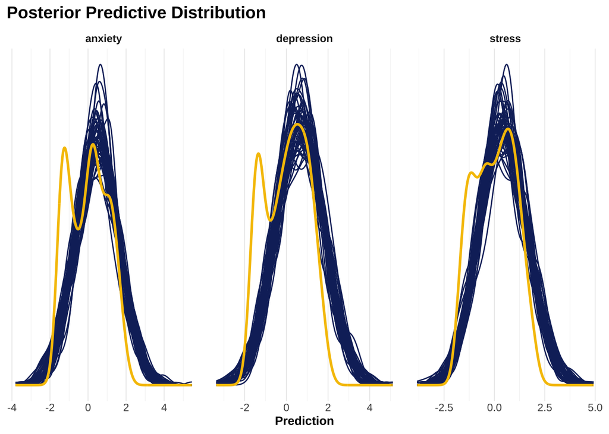

```r
# Get the Y_rep columns and rename them to be descriptive:

draws_y_rep <- draws %>% dplyr::select(contains('Y_rep'))

replacements_y_rep <- c(
  "\\,1\\]" = "_D", # Note the 1,2,3 order depends on the order of DAS in the data supplied to Stan
  "\\,2\\]" = "_A",
  "\\,3\\]" = "_S",
  "\\," = "_",
  "\\[" = "_",
  "\\]" = "")

names(draws_y_rep) <- str_replace_all(names(draws_y_rep), replacements_y_rep)

# Add posterior draw index
draws_y_rep <- draws_y_rep %>%
  mutate(draw = row_number())

# Convert to long format
y_rep_long <-
  draws_y_rep %>%
  pivot_longer(
    cols = -draw,
    names_to = "name",
    values_to = "y"
  ) %>%
  extract(
    name,
    into = c("prefix", "id", "outcome"),
    regex = "^(Y_rep)_([0-9]+)_([DAS])$",
    remove = TRUE
  ) %>%
  mutate(
    id = as.integer(id),
    outcome = recode(outcome,
                            D = "depression",
                            A = "anxiety",
                            S = "stress"
    )
  ) %>%
  dplyr::select(draw, id, outcome, y)


# Sample some posterior draws
set.seed(30314)

draw_ids <-
  y_rep_long %>%
  distinct(draw) %>%
  slice_sample(n = min(50, nrow(.))) %>%
  pull(draw)

y_rep_plot <-
  y_rep_long %>%
  filter(draw %in% draw_ids)

# Make an observed dataset in matching long format
y_obs_long <-
  data %>%
  mutate(id = row_number()) %>%
  select(
    id,
    depression = dass_depression_z,
    anxiety = dass_anxiety_z,
    stress = dass_stress_z
  ) %>%
  pivot_longer(
    cols = -id,
    names_to = "outcome",
    values_to = "y"
  )

# Plot --------------------------------------------------------------------
plot_posterior_pred <-
  ggplot() +
  geom_density(
    data = y_rep_plot,
    aes(x = y, group = draw),
    alpha = 0.01,
    color = colors_johnson[5]
  ) +
  geom_density(
    data = y_obs_long,
    aes(x = y),
    linewidth = 1,
    color = colors_johnson[3]
  ) +
  facet_wrap(~ outcome, scales = "free") +
  labs(
    title = "Posterior Predictive Distribution",
    x = "Prediction",
    y = NULL
  ) +
  theme_density

## Print to window
plot_posterior_pred %>% plot()
```

### Posterior Variance

Plot the posterior variance from the model of simulated data.

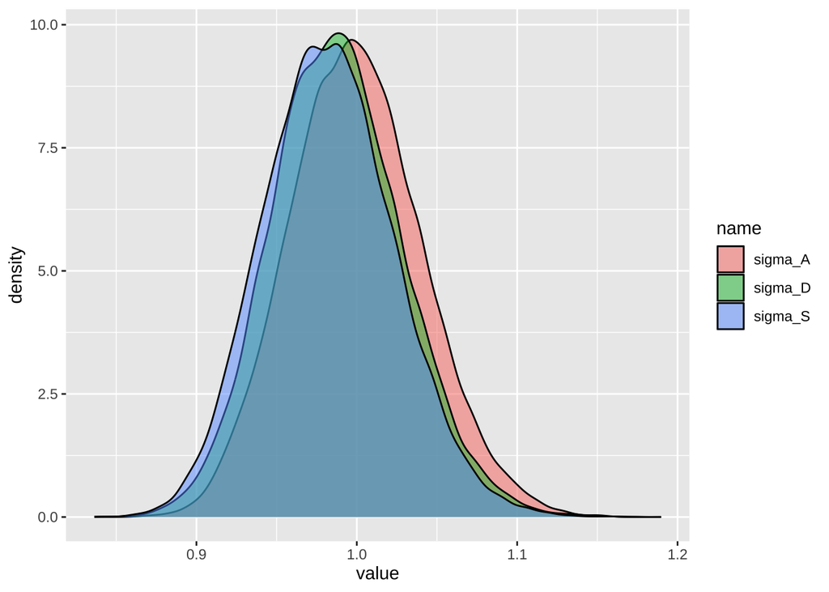

```r
draws_variance %>%
  dplyr::select(sigma_S, sigma_A, sigma_D) %>%
  pivot_longer(everything()) %>%
  ggplot(aes(value, fill = name)) +
  geom_density(alpha = .5)
```

### Posterior Covariance

Plot the posterior residual covariance from the model of simulated data.

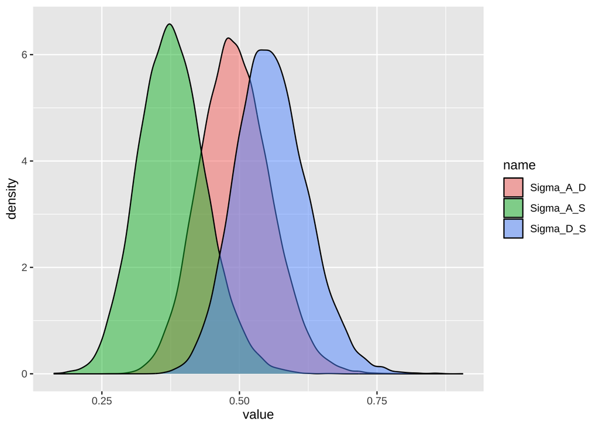

```r
draws_variance %>%
  dplyr::select(Sigma_A_D, Sigma_A_S, Sigma_D_S) %>%
  pivot_longer(everything()) %>%
  ggplot(aes(value, fill = name)) +
  geom_density(alpha = .5)
```

### Posterior Expected Means (epred)

Our estimands concern differences in means, not the means themselves.

### Contrast in means

Given these are binary variables, the coefficients are equal to the contrast in means.

```r
# Fix names
names(draws_estimands) <- str_replace_all(names(draws_estimands), replacements)

draws_estimands %>% posterior::summarise_draws()
```

```
## # A tibble: 11 × 10
##    variable      mean median    sd   mad       q5   q95  rhat ess_bulk ess_tail
##    <chr>        <dbl>  <dbl> <dbl> <dbl>    <dbl> <dbl> <dbl>    <dbl>    <dbl>
##  1 TE_VR_D     0.573  0.573  0.129 0.130  0.363   0.785 1.00    25995.   20982.
##  2 TE_VR_A     0.381  0.381  0.133 0.133  0.161   0.598 1.00    28906.   20232.
##  3 TE_VR_S     1.02   1.02   0.124 0.122  0.813   1.22  1.00    27750.   20440.
##  4 TE_P_D      0.634  0.633  0.113 0.112  0.449   0.822 1.000   29123.   20070.
##  5 TE_P_A      0.786  0.786  0.115 0.115  0.598   0.974 1.00    32602.   20560.
##  6 TE_P_S      0.282  0.282  0.112 0.112  0.0989  0.468 1.00    30856.   20392.
##  7 TE_VR_P     0.637  0.635  0.260 0.256  0.207   1.07  1.00    41573.   18416.
##  8 CDE_VG_P0_D 0.435  0.435  0.114 0.115  0.245   0.623 1.00    28156.   21104.
##  9 CDE_VG_P0_A 0.0696 0.0695 0.116 0.116 -0.121   0.261 1.00    34144.   20931.
## 10 CDE_VG_P0_S 0.192  0.192  0.114 0.115  0.00530 0.379 1.00    30952.   19854.
## 11 DE_VG_P     0.0925 0.0932 0.243 0.244 -0.307   0.493 1.00    46314.   17405.
```

- H1: Depression, Anxiety, and Stress will be worse for caregivers who are veterans.

We estimated the direct effect.

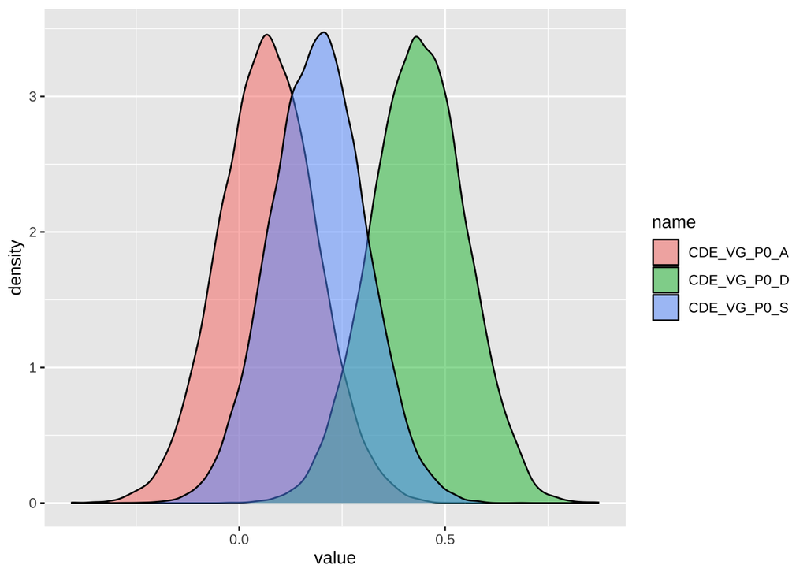

```r
draws_estimands %>%
  dplyr::select(starts_with("CDE_VG")) %>%
  pivot_longer(everything()) %>%
  ggplot(aes(value, fill = name)) +
  geom_density(alpha = .5)
```

- H2: Depression, Anxiety, and Stress will be worse for caregivers to veterans than caregivers to non-veterans.

We estimated the total effect.

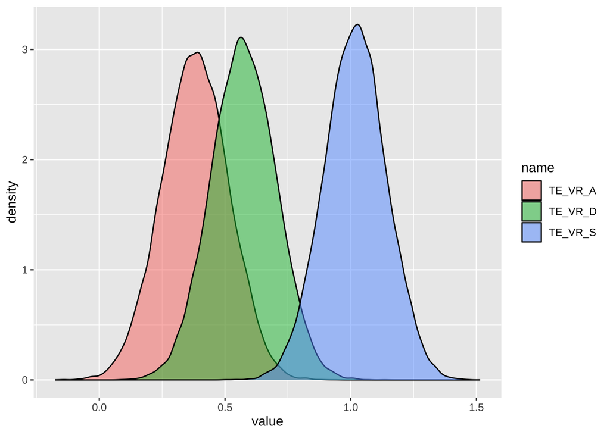

```r
draws_estimands %>%
  dplyr::select(starts_with("TE_VR") & !TE_VR_P) %>%
  pivot_longer(everything()) %>%
  ggplot(aes(value, fill = name)) +
  geom_density(alpha = .5)
```

- H3: Depression, Anxiety, and Stress will be worse for caregivers with probable PTSD.

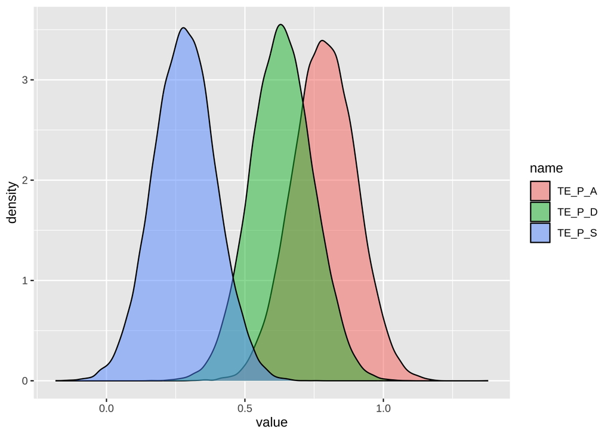

```r
draws_estimands %>%
  dplyr::select(starts_with("TE_P")) %>%
  pivot_longer(everything()) %>%
  ggplot(aes(value, fill = name)) +
  geom_density(alpha = .5)
```

- H4: Probable PTSD will be more prevalent in veteran caregivers.

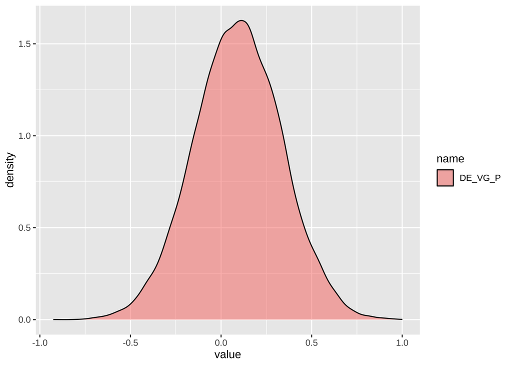

```r
draws_estimands %>%
  dplyr::select(starts_with("DE_VG_P")) %>%
  pivot_longer(everything()) %>%
  ggplot(aes(value, fill = name)) +
  geom_density(alpha = .5)
```

- H5: Probable PTSD will be more prevalent in caregivers to veterans than caregivers to non-veterans.

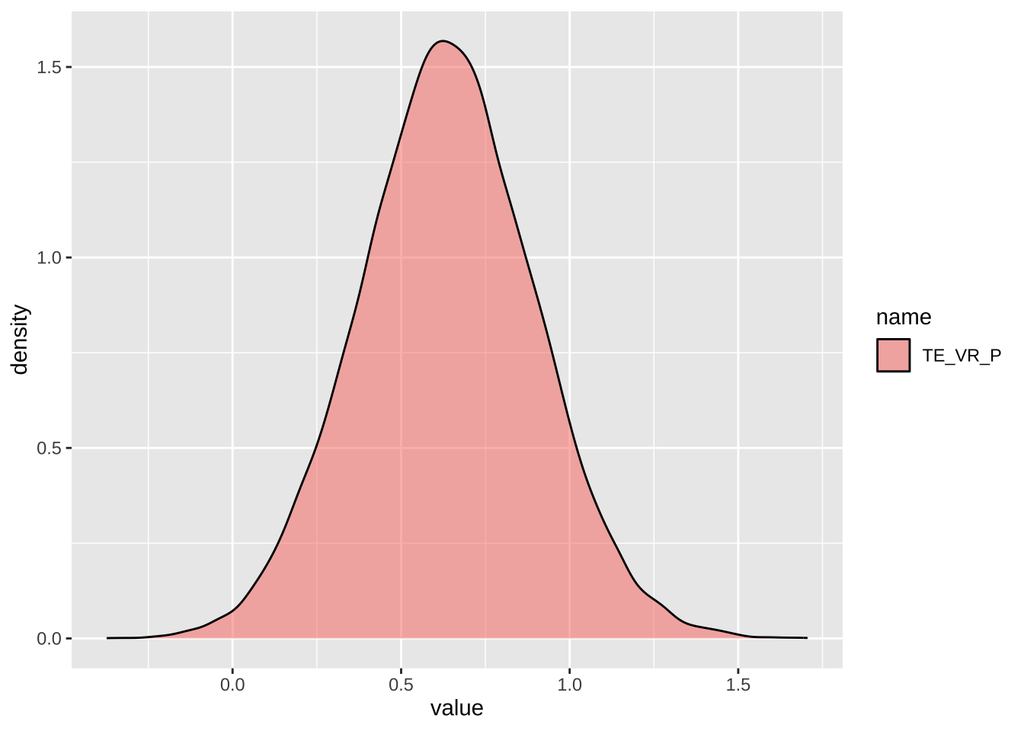

```r
draws_estimands %>%
  dplyr::select(starts_with("TE_VR_P")) %>%
  pivot_longer(everything()) %>%
  ggplot(aes(value, fill = name)) +
  geom_density(alpha = .5)
```

## Real Data Model

Having confirmed that the model will run with simulated data, it’s now time to fit the model to real data.

I’ve set up the do.R file and indidivual scripts that copy over the code blocks above, changing the simulated data to real data. Run the do.R file, which also includes a basic simulated data test.:

```r
# remove all objects from the scripts above:
rm(list = ls(all.names = TRUE))

# Then run the do file to replicate the production-grade analysis:
source(here("do.R"))
```

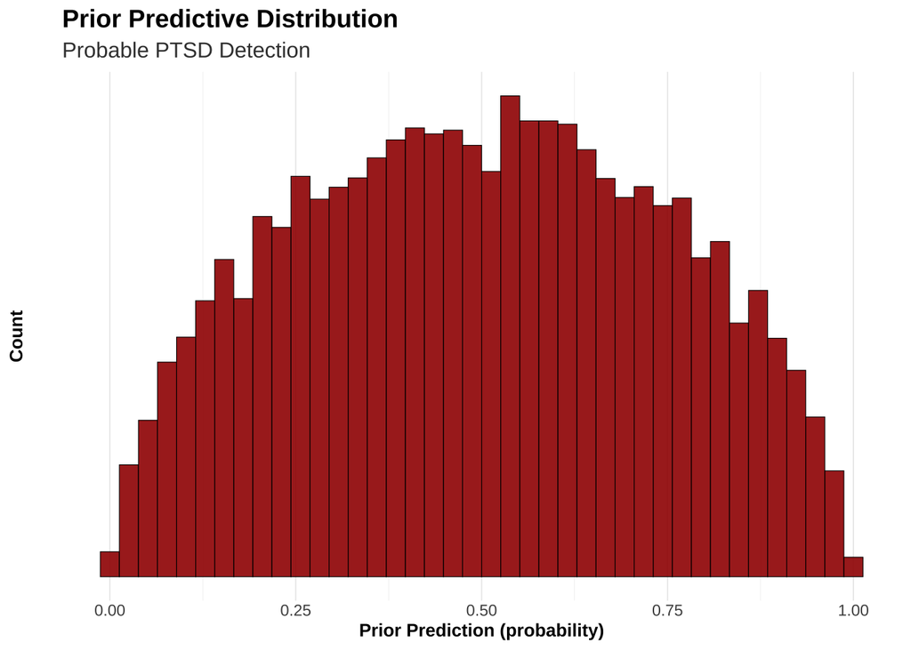

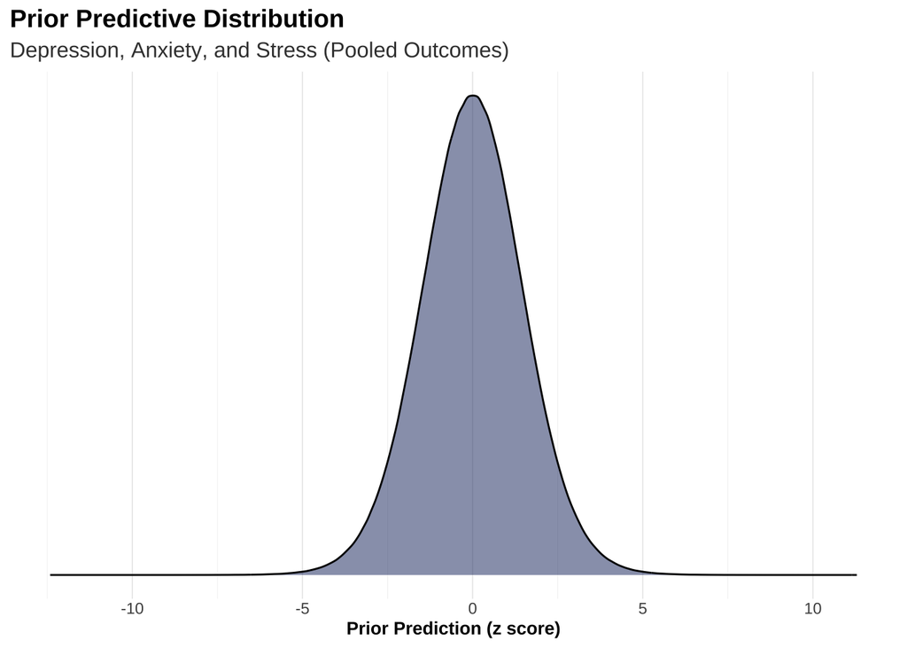

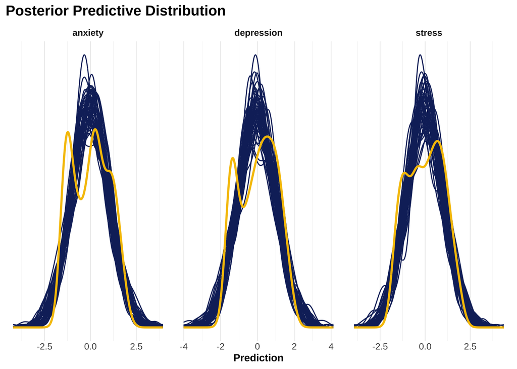

After fitting to the real data, we see some limitations of our current model. The posterior predictive check suggests the model predicts outcomes that apparent more normally distributed than the observed data. The centers of the observed and predicted distributions are similar, but the shape is not indicative of a perfect in-sample fit.

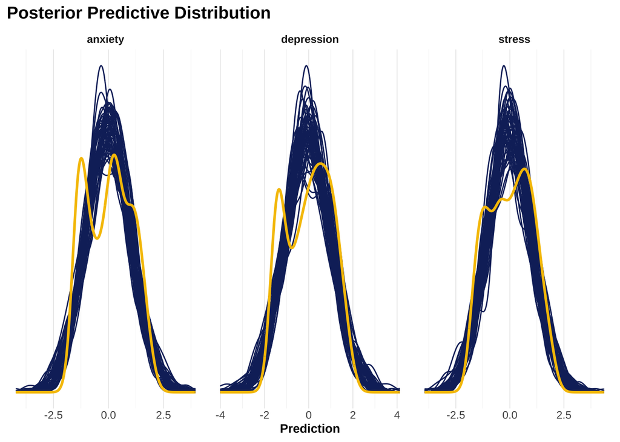

```r
plot_posterior_pred %>% plot()
```

This could indicate zero-inflation. Let’s look at a histogram of the observed data.:

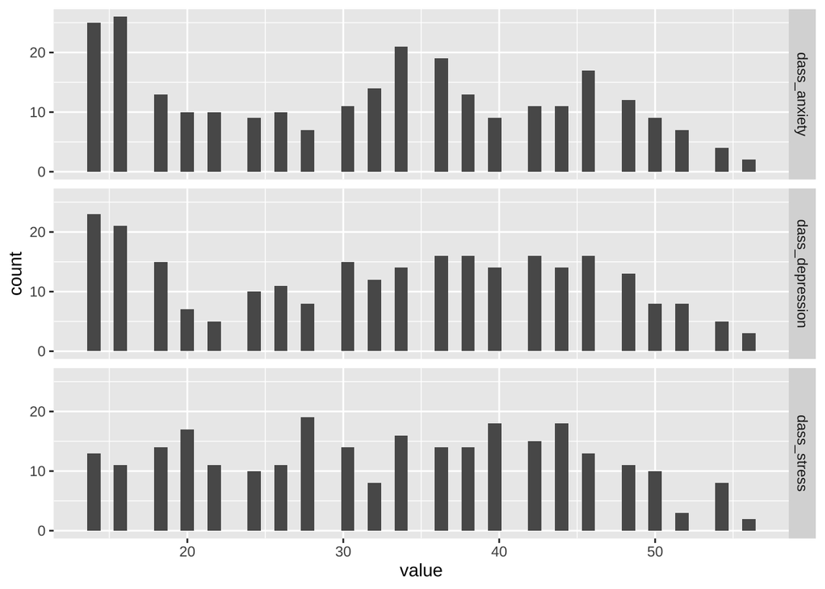

```r
data %>%
  select(dass_depression, dass_anxiety, dass_stress) %>%
  pivot_longer(everything()) %>%
  ggplot(aes(value)) +
  geom_histogram(bins = 50) +
  facet_grid(vars(name))
```

Yes, the zeros and almost zeros are contributing to the descrepancy between predicted outcomes and observed. Addressing this is not simple in the multivariate approach. But not impossible.

Now, another thing we could do is a posterior predictive check on the estimands of interest. That is, if we care about differences between veterans and non-veteran caregivers, then we compare the observed to the predicted (i.e, the sample of plausible data implied by the model).

Let’s print some preliminary results for the abstract. We may refine the model later.

- H1: Depression, Anxiety, and Stress will be worse for caregivers who are veterans. (CDE_VG_P0_D, CDE_VG_P0_A, CDE_VG_P0_S) – Depression: mean = 0.29, 95% CI = 0.05 - 0.53 – Anxiety: mean = 0.35, 95% CI = 0.12 - 0.59 – Stress: mean = 0.28, 95% CI = 0.04 - 0.51
- H2: Depression, Anxiety, and Stress will be worse for caregivers to veterans than caregivers to non-veterans. (TE_VR_D, TE_VR_A, TE_VR_S) – Depression: mean = 0.13, 95% CI = -0.17 - 0.44 – Anxiety: mean = 0.15, 95% CI = -0.14 - 0.45 – Stress: mean = 0.04, 95% CI = -0.26 - 0.33
- H3: Depression, Anxiety, and Stress will be worse for caregivers with probable PTSD. (TE_P_D, TE_P_A, TE_P_S) – Depression: mean = 0.65, 95% CI = 0.42 — 0.87 – Anxiety: mean = 0.55, 95% CI = 0.32 — 0.77 – Stress: mean = 0.58, 95% CI = 0.36 — 0.79
- H4: Probable PTSD will be more prevalent in veteran caregivers. (DE_VG_P) mean = 0.72, 95% CI = 0.08 — 1.37
- H5: Probable PTSD will be more prevalent in caregivers to veterans than caregivers to non-veterans. (TE_VR_P) mean = 0.93, 95% CI = 0.15 — 1.71

```r
draws_estimands %>% posterior::summarise_draws(~mean(.x), ~quantile(.x, probs = c(0.025, 0.975))) %>%
  mutate(across(where(is.numeric), ~ round(.x, 2)))
```

```
## # A tibble: 11 × 4
##    variable    `~mean(.x)` `2.5%` `97.5%`
##    <chr>             <dbl>  <dbl>   <dbl>
##  1 TE_VR_D            0.13  -0.17    0.44
##  2 TE_VR_A            0.15  -0.14    0.45
##  3 TE_VR_S            0.04  -0.26    0.33
##  4 TE_P_D             0.65   0.42    0.87
##  5 TE_P_A             0.55   0.32    0.77
##  6 TE_P_S             0.58   0.36    0.79
##  7 TE_VR_P            0.93   0.15    1.71
##  8 CDE_VG_P0_D        0.29   0.05    0.53
##  9 CDE_VG_P0_A        0.35   0.12    0.59
## 10 CDE_VG_P0_S        0.28   0.04    0.51
## 11 DE_VG_P            0.72   0.08    1.37
```

## Abstract

We estimated the difference in depression, anxiety, and stress between caregivers based on their personal veteran status, the veteran status of their care recipient, and PTSD status. We modeled these responses, measured with the DASS-21, using a Bayesian multivariate multiple regression. Preliminary results suggest that depression, anxiety, and stress are worse for caregivers who veterans themselves (Direct Effect on Depression: posterior mean = 0.29, 95% CI = 0.05 - 0.53; Anxiety: mean = 0.35, 95% CI = 0.12 - 0.59; Stress: mean = 0.28, 95% CI = 0.04 - 0.51). However, these concerns are less likely to be influenced by veteran status of the recipient (Total Effect on Depression: posterior mean = 0.13, 95% CI = -0.17 - 0.44; Anxiety: mean = 0.15, 95% CI = -0.14 - 0.45; Stress: mean = 0.04, 95% CI = -0.26 - 0.33). These concerns were reliably worse for caregivers with PTSD (Total Effect on Depression: mean = 0.65, 95% CI = 0.42 — 0.87; Anxiety: mean = 0.55, 95% CI = 0.32 — 0.77; Stress: mean = 0.58, 95% CI = 0.36 — 0.79), which was more likely for caregivers who were veterans (Direct Effect: posterior mean = 0.72, 95% CI = 0.08 — 1.37) and caring for veterans (Total effect: posterior mean = 0.93, 95% CI = 0.15 — 1.71).

## Write Up

### Directed Acyclical Graph

To aid in causal identification and covariate selection, we used directed acyclic graphs (DAGs). It is not our argument that the data support a causal interpretation. Indeed, cross-sectional data rarely support a causal interpretation. Rather, we want to make it clear what assumptions would need to be true in order to interpret the results causally.

### Mathematical specification

Priors were chosen to be weakly informative (Gelman et al., 2008). To aid in prior specification, we scaled the outcome data and centered the binary predictors. We tested the priors using prior predictive simulations to ensure that pre-data predictions span the range of plausible outcomes. This resulted in more restrictive priors than our original specification.

### References

Gelman, A., Jakulin, A., Pittau, M. G., & Su, Y.-S. (2008). A weakly informative default prior distribution for logistic and other regression models. The Annals of Applied Statistics, 2(4). https://doi.org/10.1214/08-AOAS191